# General Test - Q2

[figure not shown]

#### Instituto de Matemática e Estatística da Universidade de São Paulo

#### MAC0459 - Ciência e Engenheria de Dados

##### Victor Senoguchi Borges NUSP 9298580

##### Professor: Roberto Hirata Junior

##### General Test - 2021

###### By uploding this test I declare that I have worked on it alone and I know that I can be failed in the discipline if I break this circle of confidence.

São Paulo, Janeiro de 2022

# Importes iniciais

```python
import pandas as pd
import numpy as np
import seaborn as sns
import matplotlib.pyplot as plt
from mpl_toolkits.mplot3d import Axes3D
```

# Q2.

Treine e ajuste uma árvore de decisão e uma Random Forest para um dos conjuntos de dados você trabalhou em grupo durante as aulas práticas. Em seu notebook, apresente o conjunto de dados, apresente a parte relevante da análise exploratória de dados para esta tarefa, adicione uma análise não supervisionada, o problema de aprendizado de máquina supervisionado (ML), os modelos, compare o resultados e escrever uma pequena conclusão.

## Conjunto de dados

O conjunto de dados escolhido para a realização desta tarefa foi o [Heart Disease UCI](https://www.kaggle.com/ronitf/heart-disease-uci).

Este é um subconjunto de 14 atributos de um banco de dados que contém 76. O campo "target" refere-se à presença de doença cardíaca no paciente. É um número inteiro com valor de 0 (sem presença) e 1 (com presença).

### Descrição do conjunto de dados

```
1. age - idade em anos.
2. sex - sexo (1 = masculino; 0 = feminino).
3. cp - tipo de dor no peito
    Valor 0: angina típica;
    Valor 1: angina atípica;
    Valor 2: dor não anginosa;
    Valor 3: assintomática
```

### Descrição do conjunto de dados

```
4. trestbps - pressão sanguínea em repouso
5. chol - colesterol sérico em ml/dl
6. fbs - açúcar no sangue em jejum maior que 120 ml/dl
7. restecg - resultados eletrocardiográficos em repouso
8. thalach - frequência cardíaca máxima alcançada
9. exang - angina induzida por exercício (1 = sim; 0 não)
```

### Descrição do conjunto de dados

```
10. oldpeak - depressão ST induzida por exercício em
relação ao repouso
11. slope - inclinação da extremidade do segmento ST
no exercício
    Valor 1: inclinação para cima;
    Valor 2: plano;
    Valor 3: inclinação para baixo
```

### Descrição do conjunto de dados

[output not shown]

## Análise exploratória de dados

### Carregando o conjunto de dados

```python
df = pd.read_csv('heart.csv')
```

```python
print(list(df.columns))
```

```
['age', 'sex', 'cp', 'trestbps', 'chol', 'fbs', 'restecg', 'thalach', 'exang', 'oldpeak', 'slope', 'ca', 'thal', 'target']
```

```python
df.describe()[['age', 'trestbps', 'chol', 'thalach', 'oldpeak', 'thal']]
```

|  | age | trestbps | chol | thalach | oldpeak | thal |
| --- | --- | --- | --- | --- | --- | --- |
| count | 303.000000 | 303.000000 | 303.000000 | 303.000000 | 303.000000 | 303.000000 |
| mean | 54.366337 | 131.623762 | 246.264026 | 149.646865 | 1.039604 | 2.313531 |
| std | 9.082101 | 17.538143 | 51.830751 | 22.905161 | 1.161075 | 0.612277 |
| min | 29.000000 | 94.000000 | 126.000000 | 71.000000 | 0.000000 | 0.000000 |
| 25% | 47.500000 | 120.000000 | 211.000000 | 133.500000 | 0.000000 | 2.000000 |
| 50% | 55.000000 | 130.000000 | 240.000000 | 153.000000 | 0.800000 | 2.000000 |
| 75% | 61.000000 | 140.000000 | 274.500000 | 166.000000 | 1.600000 | 3.000000 |
| max | 77.000000 | 200.000000 | 564.000000 | 202.000000 | 6.200000 | 3.000000 |

```python
sns.set_style('white')
```

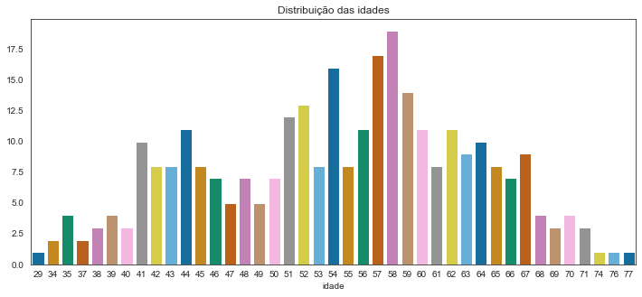

```python
fig = plt.figure(figsize=(12,5))
ax = sns.countplot(data = df, x = 'age', palette = 'colorblind')
plt.title('Distribuição das idades')
plt.xlabel('idade')
plt.ylabel('')
plt.show()
```

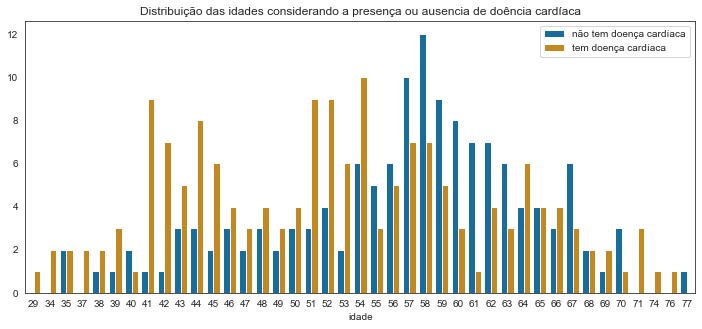

```python
fig = plt.figure(figsize=(12,5))
ax = sns.countplot(data = df, x = 'age', palette = 'colorblind', hue = 'target')
plt.title('Distribuição das idades considerando a presença ou ausencia de doência cardíaca')
plt.xlabel('idade')
plt.ylabel('')
plt.legend(loc='upper right', labels=['não tem doença cardíaca', 'tem doença cardíaca'])
plt.show()
```

É possível observar que os casos em que número de casos em que o número de pessoas com com doença cardíaca é maior que o número de pessoas sem doença cardíaca acontece nas idades mais jovens, uma das explicações para tal fato é que as pessoas mais jovens tendem a procurar assistência médica somente quando tem algum problema de saúde evidente.

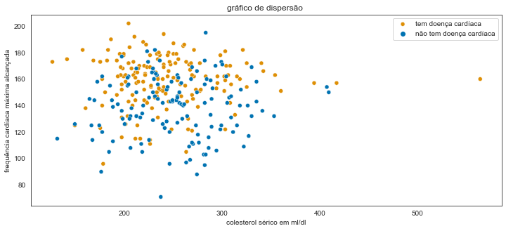

```python
fig = plt.figure(figsize=(12,5))
ax = sns.scatterplot(data = df, x = 'chol', y = 'thalach', palette = 'colorblind', hue = 'target')
plt.title('gráfico de dispersão ')
plt.xlabel('colesterol sérico em ml/dl')
plt.ylabel('frequência cardíaca máxima alcançada')
plt.legend(loc='upper right', labels=['tem doença cardíaca', 'não tem doença cardíaca'])
plt.show()
```

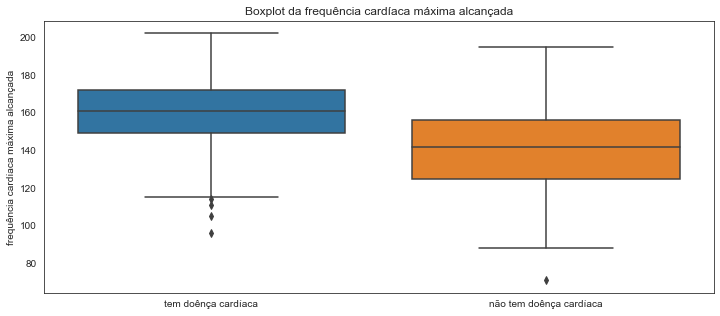

```python
labels = {0: 'não tem doênça cardíaca', 1: 'tem doênça cardíaca'}
x = [labels[target] for target in df.target]
fig = plt.figure(figsize=(12,5))
ax = sns.boxplot(x = x, y = df.thalach)
plt.title('Boxplot da frequência cardíaca máxima alcançada')
plt.ylabel('frequência cardíaca máxima alcançada')
plt.show()
```

Podemos observar tanto no gráfico de dispersão quanto no boxplot que a maior parte dos casos em que a pessoa tem doência cardíaca sua frequência cardíaca máxima alcançada é superior a $150$ bpm.

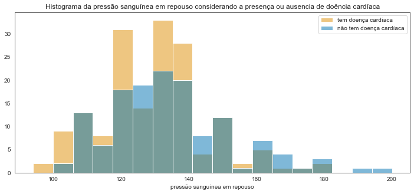

```python
fig = plt.figure(figsize=(12,5))
ax = sns.histplot(data = df, x = 'trestbps', palette = 'colorblind', hue = 'target')
plt.title('Histograma da pressão sanguínea em repouso considerando a presença ou ausencia de doência cardíaca')
plt.xlabel('pressão sanguínea em repouso')
plt.ylabel('')
plt.legend(loc='upper right', labels=[ 'tem doença cardíaca', 'não tem doença cardíaca'])
plt.show()
```

Visualizando o histograma acima, podemos observar que ter uma pressão sanguínea em repouso baixa pode ser um bom indício de doença cardíaca.

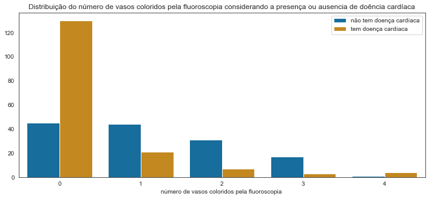

```python
fig = plt.figure(figsize=(12,5))
ax = sns.countplot(data = df, x = 'ca', palette = 'colorblind', hue = 'target')
plt.title('Distribuição do número de vasos coloridos pela fluoroscopia considerando a presença ou ausencia de doência cardíaca')
plt.xlabel('número de vasos coloridos pela fluoroscopia ')
plt.ylabel('')
plt.legend(loc='upper right', labels=['não tem doença cardíaca', 'tem doença cardíaca'])
plt.show()
```

É importante notar que a maior parte dos casos são de pessoas que tem poucos vasos número de vasos coloridos pela fluoroscopia, além disso, é evidente que a maior parte dos casos em que a pessoa tem doença cardíaca o número de vasos coloridos pela fluoroscopia é igual a zero.

## Preparação dos Dados

#### Importes necessários

```python
from sklearn.model_selection import train_test_split
from sklearn import metrics
```

```python
X = df.drop('target', axis = 1)
y = df['target']
```

```python
feature_names = X.columns
labels = ['não tem doença cardíaca',
          'tem doença cardíaca ']
```

```python
X_train, X_test, y_train, y_test = train_test_split(X, y,
                                                    test_size = 0.3,
                                                    random_state = 42)
```

## Análise não supervisionada

### Análise de componentes principais

#### Importes necessários

```python
from sklearn.decomposition import PCA
```

#### PCA em 2D

```python
pca = PCA(n_components = 2)
X_r = pca.fit(X).transform(X)
```

```python
def pca_2d_plot(X_r, labels):

    plt.figure(figsize=((8,4)))
    colors = ['turquoise', 'red']
    lw = 2

    for color, i, label in zip(colors, [0, 1], labels):
        plt.scatter(X_r[y == i, 0], X_r[y == i, 1],
                    color=color, alpha=.8,
                    label = label, lw=lw)
    plt.legend(loc='best', shadow=False, scatterpoints=1)
    plt.title('PCA of Heart Disease Dataset')

    plt.show()

def componentes_principais(df, pca, X_r):

    n_pcs = pca.components_.shape[0]
    most_important = [np.abs(pca.components_[i]).argmax() for i in range(n_pcs)]
    feature_names = list(df.columns)
    most_important_names = [feature_names[most_important[i]] for i in range(n_pcs)]
    return {'CP{}'.format(i+1): most_important_names[i] for i in range(n_pcs)}
```

```
{'CP1': 'chol', 'CP2': 'thalach'}
razão de variância explicada (primeiras duas componentes): [0.7475642  0.15037022]
```

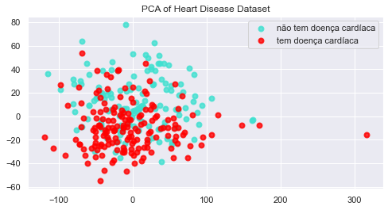

```python
print(componentes_principais(df, pca, X_r))
print('razão de variância explicada (primeiras duas componentes): %s'
      % str(pca.explained_variance_ratio_))
pca_2d_plot(X_r, labels)
```

#### PCA em 3D

```python
pca = PCA(n_components = 3)
X_r = pca.fit(X).transform(X)
```

```python
def pca_3d_plot(X_r, y, labels):

    Xax = X_r[:,0]
    Yax = X_r[:,1]
    Zax = X_r[:,2]

    colors = ['turquoise', 'red']
    marker = {0:'*',1:'o'}
    fig = plt.figure(figsize=(7,5))
    ax = fig.add_subplot(111, projection='3d')
    fig.patch.set_facecolor('white')
    for color, i, label in zip(colors, [0, 1], labels):
        ix = np.where(y==i)
        ax.scatter(Xax[ix], Yax[ix], Zax[ix],
                   c = color, marker = marker[i],
                   s = 10, label = label)
    ax.set_xlabel("Primeira componente principal", fontsize = 8)
    ax.set_ylabel("Segunda componente principal", fontsize = 8)
    ax.set_zlabel("Terceira componente principal", fontsize = 8)
    ax.legend()
    plt.title('PCA of Heart Disease Dataset')
```

```
{'CP1': 'chol', 'CP2': 'thalach', 'CP3': 'trestbps'}
razão de variância explicada (primeiras três componentes): [0.7475642  0.15037022 0.08459685]
```

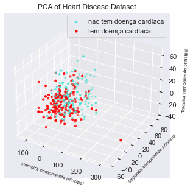

```python
print(componentes_principais(df, pca, X_r))
print('razão de variância explicada (primeiras três componentes): %s'
      % str(pca.explained_variance_ratio_))
pca_3d_plot(X_r, y, labels)
```

Podemos notar que tanto para $n=2$, quanto para $n=3$, há uma grande sobreposição das classes e portanto é difícil fazer algum agrupamento que separe as classes de maneira satisfatória.

## Árvore de decisão

### Importes necessários

```python
from sklearn import tree
from sklearn.model_selection import GridSearchCV
from sklearn.metrics import confusion_matrix
from sklearn.metrics import make_scorer
from sklearn.metrics import accuracy_score
from sklearn.metrics import f1_score
from sklearn.metrics import precision_score
from sklearn.metrics import recall_score
from sklearn.metrics import classification_report
```

### Seleção do modelo

```python
def make_grid(model, param_grid, scoring, X, y):

    gs = GridSearchCV(estimator = model,
                      scoring = scoring,
                      param_grid = param_grid,
                      verbose = True,
                      n_jobs = -1,
                      refit = False).fit(X, y)

    grid = pd.DataFrame(gs.cv_results_)

    grid.rename(columns = {"rank_test_accuracy": "accuracy_rank",
                           "mean_test_accuracy": "accuracy",
                           "rank_test_precision": "precision_rank",
                           "mean_test_precision": "precision",
                           "rank_test_recall": "recall_rank",
                           "mean_test_recall": "recall",
                           "rank_test_f1": "f1_rank",
                           "mean_test_f1": "f1"},
                inplace = True)

    grid.sort_values(by = ["recall_rank",
                           "accuracy_rank",
                           "f1_rank"],
                     inplace = True)

    return grid[["params", "recall_rank",
                 "recall", "accuracy_rank",
                 "accuracy", "f1_rank",
                 "f1", "precision"]]

def select(grid, param = None):

    if param is None:
        return grid["params"].iloc[0]
    else:
        return grid["params"].iloc[0][param]
```

```python
param_grid = [{'max_depth': [2,3,4,5,6],
               'min_samples_split': [2,4,6,8,10]}]

scoring = {"accuracy" : make_scorer(accuracy_score),
           "precision": make_scorer(precision_score, average = "macro"),
           "recall": make_scorer(recall_score, average = "macro"),
           "f1" : make_scorer(f1_score, average = "macro")}

seed = 2022
```

```python
decision_tree = tree.DecisionTreeClassifier(random_state = seed)
decision_tree_grid = make_grid(decision_tree, param_grid,
                               scoring, X_train, y_train)
```

```
Fitting 5 folds for each of 25 candidates, totalling 125 fits
```

```python
decision_tree_grid.head(10)
```

|  | params | recall_rank | recall | accuracy_rank | accuracy | f1_rank | f1 | precision |
| --- | --- | --- | --- | --- | --- | --- | --- | --- |
| 5 | {'max_depth': 3, 'min_samples_split': 2} | 1 | 0.802277 | 1 | 0.806534 | 1 | 0.800997 | 0.819860 |
| 6 | {'max_depth': 3, 'min_samples_split': 4} | 1 | 0.802277 | 1 | 0.806534 | 1 | 0.800997 | 0.819860 |
| 7 | {'max_depth': 3, 'min_samples_split': 6} | 1 | 0.802277 | 1 | 0.806534 | 1 | 0.800997 | 0.819860 |
| 8 | {'max_depth': 3, 'min_samples_split': 8} | 1 | 0.802277 | 1 | 0.806534 | 1 | 0.800997 | 0.819860 |
| 9 | {'max_depth': 3, 'min_samples_split': 10} | 1 | 0.802277 | 1 | 0.806534 | 1 | 0.800997 | 0.819860 |
| 14 | {'max_depth': 4, 'min_samples_split': 10} | 6 | 0.791190 | 6 | 0.792248 | 6 | 0.789541 | 0.796325 |
| 13 | {'max_depth': 4, 'min_samples_split': 8} | 7 | 0.790275 | 6 | 0.792248 | 7 | 0.788517 | 0.798248 |
| 12 | {'max_depth': 4, 'min_samples_split': 6} | 8 | 0.789359 | 6 | 0.792248 | 8 | 0.787180 | 0.801582 |
| 10 | {'max_depth': 4, 'min_samples_split': 2} | 9 | 0.784359 | 9 | 0.787597 | 9 | 0.782303 | 0.797371 |
| 11 | {'max_depth': 4, 'min_samples_split': 4} | 9 | 0.784359 | 9 | 0.787597 | 9 | 0.782303 | 0.797371 |

```python
params = select(decision_tree_grid)
params
```

```
{'max_depth': 3, 'min_samples_split': 2}
```

```python
clf = tree.DecisionTreeClassifier(max_depth = params['max_depth'],
                                  min_samples_split = params['min_samples_split'],
                                  random_state = seed)
clf.fit(X_train, y_train)
```

```
DecisionTreeClassifier(max_depth=3, random_state=2022)
```

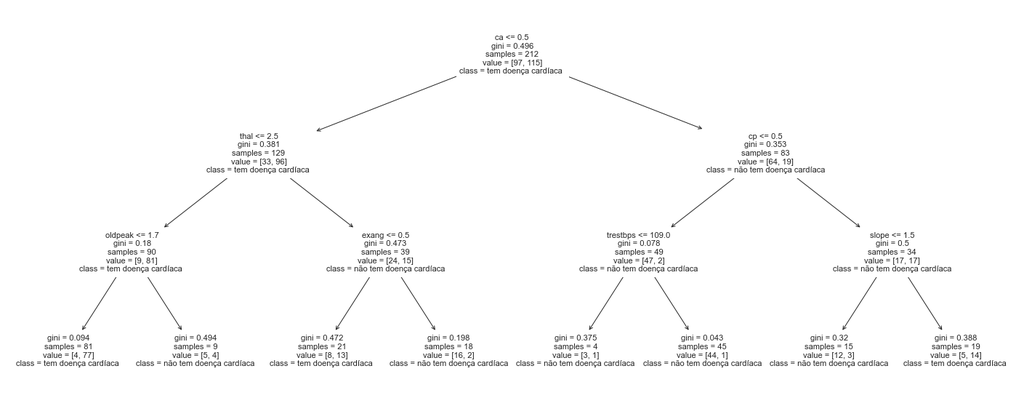

```python
plt.figure(figsize=(25,10))
tree.plot_tree(clf,
               feature_names = feature_names,
               class_names = labels)
plt.show()
```

### Avaliação

```python
def heatmap(confusion_matrix):
    matrix_df = pd.DataFrame(confusion_matrix)
    plt.figure(figsize=((10,7)))
    ax = plt.axes()
    sns.set(font_scale=1)
    sns.heatmap(matrix_df, annot=True, fmt="g", ax=ax, cmap="magma")
    ax.set_title('Matriz de confusão - Árvore de decisão')
    ax.set_xlabel("Predição", fontsize = 15)
    ax.set_xticklabels(list(labels))
    ax.set_ylabel("Condição verdadeira", fontsize=15)
    ax.set_yticklabels(list(labels), rotation = 0)
    plt.show()
```

#### Conjunto de treinamento

```python
train_pred_decision_tree = clf.predict(X_train)
```

```python
confusion_matrix = metrics.confusion_matrix(y_train,
                                            train_pred_decision_tree)
```

##### Heatmap

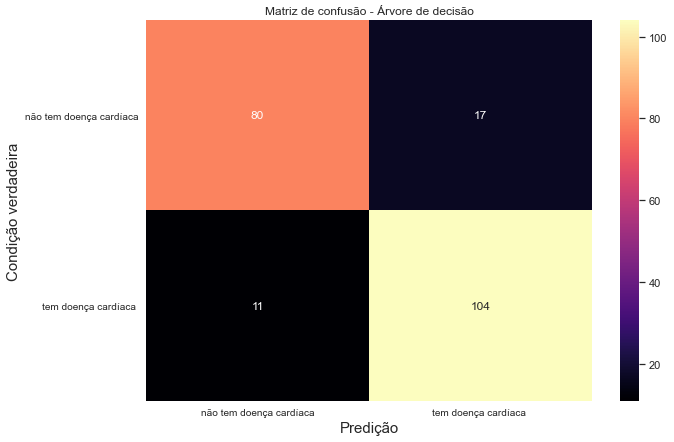

```python
heatmap(confusion_matrix)
```

##### Relatório de classificação

```python
print(classification_report(y_train, train_pred_decision_tree))
```

```
              precision    recall  f1-score   support

           0       0.88      0.82      0.85        97
           1       0.86      0.90      0.88       115

    accuracy                           0.87       212
   macro avg       0.87      0.86      0.87       212
weighted avg       0.87      0.87      0.87       212
```

#### Conjunto de teste

```python
test_pred_decision_tree = clf.predict(X_test)
```

```python
confusion_matrix = metrics.confusion_matrix(y_test,
                                            test_pred_decision_tree)
```

##### Heatmap

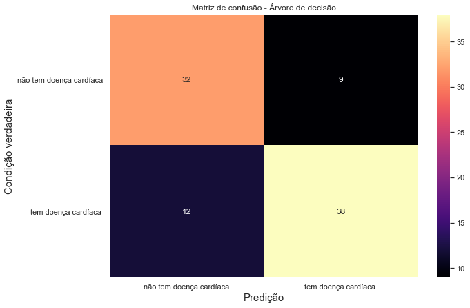

```python
heatmap(confusion_matrix)
```

##### Relatório de classificação

```python
print(classification_report(y_test, test_pred_decision_tree ))
```

```
              precision    recall  f1-score   support

           0       0.73      0.78      0.75        41
           1       0.81      0.76      0.78        50

    accuracy                           0.77        91
   macro avg       0.77      0.77      0.77        91
weighted avg       0.77      0.77      0.77        91
```

## Random Forest

### Importes Necessários

```python
from sklearn.ensemble import RandomForestClassifier
```

### Seleção do modelo

```python
param_grid = [{'n_estimators': [10, 25, 50, 75, 100],
               'max_depth': [2,3,4,5,6],
               'min_samples_split': [2,4,6,8,10]}]

scoring = {"accuracy" : make_scorer(accuracy_score),
           "precision": make_scorer(precision_score, average = "macro"),
           "recall": make_scorer(recall_score, average = "macro"),
           "f1" : make_scorer(f1_score, average = "macro")}

seed = 2022
```

```python
random_forest = RandomForestClassifier(random_state = seed)
random_forest_grid = make_grid(random_forest, param_grid,
                               scoring, X_train, y_train)
```

```
Fitting 5 folds for each of 125 candidates, totalling 625 fits
```

```python
random_forest_grid.head()
```

|  | params | recall_rank | recall | accuracy_rank | accuracy | f1_rank | f1 | precision |
| --- | --- | --- | --- | --- | --- | --- | --- | --- |
| 121 | {'max_depth': 6, 'min_samples_split': 10, 'n_e... | 1 | 0.845057 | 1 | 0.848726 | 1 | 0.845113 | 0.854326 |
| 1 | {'max_depth': 2, 'min_samples_split': 2, 'n_es... | 2 | 0.837574 | 2 | 0.844186 | 2 | 0.839715 | 0.853713 |
| 6 | {'max_depth': 2, 'min_samples_split': 4, 'n_es... | 2 | 0.837574 | 2 | 0.844186 | 2 | 0.839715 | 0.853713 |
| 11 | {'max_depth': 2, 'min_samples_split': 6, 'n_es... | 2 | 0.837574 | 2 | 0.844186 | 2 | 0.839715 | 0.853713 |
| 16 | {'max_depth': 2, 'min_samples_split': 8, 'n_es... | 2 | 0.837574 | 2 | 0.844186 | 2 | 0.839715 | 0.853713 |

```python
params = select(random_forest_grid)
params
```

```
{'max_depth': 6, 'min_samples_split': 10, 'n_estimators': 25}
```

```python
clf = RandomForestClassifier(n_estimators = params['n_estimators'],
                             max_depth = params['max_depth'],
                             min_samples_split = params['min_samples_split'],
                             random_state = seed)
clf.fit(X_train, y_train)
```

```
RandomForestClassifier(max_depth=6, min_samples_split=10, n_estimators=25,
                       random_state=2022)
```

### Avaliação

#### Conjunto de treinamento

```python
train_pred_random_forest = clf.predict(X_train)
```

```python
confusion_matrix = metrics.confusion_matrix(y_train,
                                            train_pred_random_forest)
```

##### Heatmap

[figure not shown]

```python
heatmap(confusion_matrix)
```

##### Relaorio de classificação

```python
print(classification_report(y_train, train_pred_random_forest))
```

```
              precision    recall  f1-score   support

           0       0.96      0.93      0.94        97
           1       0.94      0.97      0.95       115

    accuracy                           0.95       212
   macro avg       0.95      0.95      0.95       212
weighted avg       0.95      0.95      0.95       212
```

#### Conjunto de teste

```python
test_pred_random_forest = clf.predict(X_test)
```

```python
confusion_matrix = metrics.confusion_matrix(y_test,
                                            test_pred_random_forest)
```

##### Heatmap

[figure not shown]

```python
heatmap(confusion_matrix)
```

##### Relatório de classificação

```python
print(classification_report(y_test, test_pred_random_forest))
```

```
              precision    recall  f1-score   support

           0       0.82      0.78      0.80        41
           1       0.83      0.86      0.84        50

    accuracy                           0.82        91
   macro avg       0.82      0.82      0.82        91
weighted avg       0.82      0.82      0.82        91
```

## Conclusão

Conseguímos ao longo de toda a análise, sendo ela exploratória, supervisionada ou não supervisionada identificar que algumas variáveis são mais determinantes para a presença de doença cardíaca ou não. Além disso, conseguimos verificar que o modelo de Random Forest indicadores melhores que o modelo de árvore de decisao. Entretanto também é possível notar um sobreajuste do Random Forest sobre o conjunto de treinamento, o ideal talve seja usar um conjunto de validação para ajustar os modelos, porém não temos muitos dados para faze-lo.